# Clase2_py_inter

## Curso de introducción a la programación con Python

**Autor: Luis Fernando Apáez Álvarez**  
-Curso PyM-  
Clase 2: Más sobre NumPy y Pandas  
Fecha: 29 de noviembre del 2022

### Contenido

Librería NumPy (parte 2)

Más sobre filtros

Agregar y remover datos

Resumiendo datos

Operaciones vectorizadas

Librería Pandas (parte 2)

Ordenamientos

Filtros

En esta clase indagaremos sobre más conceptos dentro de las librerías NumPy y Pandas

### Librería NumPy (parte 2)

#### Más sobre filtros

En la clase pasada vimos que podíamos realizar filtros sobre arrays utilizando máscaras booleanas. Retomenos dicha idea, para lo cual

```python
# Importamos la libreria necesaria
import numpy as np
```

crearemos un array que represente en la primer columna un ID de estudiante y en la segunda la calificación final de éste

```python
array1 = np.array([ [1, 10],
                    [2, 6],
                    [3, 7.5],
                    [4, 5],
                    [5, 9.2],
                    [6, 5.8] ])
print(array1)
```

```
[[ 1.  10. ]
 [ 2.   6. ]
 [ 3.   7.5]
 [ 4.   5. ]
 [ 5.   9.2]
 [ 6.   5.8]]
```

Lo que haremos ahora será filtrar el `array1` para aquellos valores en la segunda columna que sean mayores iguales a 6 (es decir, obtendremos los estudiantes que aprobaron).

```python
# Realizaremos un filtrado especifico sobre la segunda columna
#         seleccionamos| seleccio-| condi-
#         todas las    | namos la | ción
#         filas del    | segunda  |
#         array        | columna  |
mask = array1[:,         1]       >= 6

# Veamos el array filtrado
print(array1[mask])
```

```
[[ 1.  10. ]
 [ 2.   6. ]
 [ 3.   7.5]
 [ 5.   9.2]]
```

Donde al array dado:

$$ \left(\begin{array}{cc} 1 & 10 \\ 2 & 6\\ 3 & 7.5\\ 4 & 5\\ 5 & 9.2\\ 6 & 5.8 \end{array}\right) $$

al realizarle el filtro sobre la segunda columna con la condición dada obtenemos:

$$ \left(\begin{array}{cc} 1 & True \\ 2 & True\\ 3 & True\\ 4 & False\\ 5 & True\\ 6 & False \end{array}\right) \ \ \rightarrow \ \ \left(\begin{array}{cc} 1 & 10 \\ 2 & 6\\ 3 & 7.5\\ - & -\\ 5 & 9.2\\ - & - \end{array}\right) $$

De manera totalmente análoga podemos utilizar `np.where()` para realizar filtrados, siendo éste una alternativa de uso de las máscaras booleanas. Por ejemplo:

```python
#                   condicion de filtrado
filtrado = np.where( array1[:, 1] >= 6 )

# indaguemos sobre nuestro filtro
print(filtrado)
```

```
(array([0, 1, 2, 4], dtype=int64),)
```

El método `np.where()` devuele una tupla de arrays, donde en este caso el array que se devuelve hace alusión a los índices de las filas que cumplen con la condición que específicamos

$$ \begin{array}{cc} \textrm{Índice fila}\\ 0 \\ 1\\ 2 \\ -\\ 4\\ - \end{array} \left(\begin{array}{cc} & \\ 1 & 10 \\ 2 & 6\\ 3 & 7.5\\ - & -\\ 5 & 9.2\\ - & - \end{array}\right) $$

```python
# De tal modo obtenemos el array filtrado
print(array1[filtrado])
```

```
[[ 1.  10. ]
 [ 2.   6. ]
 [ 3.   7.5]
 [ 5.   9.2]]
```

Luego, dentro de la tupla de arrays que puede retornar `np.where()` están otros arrays de índices para el caso en el que estemos trabajando con arrays multidimensionales

[figure not shown]

donde se nos puede regresar, por ejemplo para un array de 3 dimensiones, un array correspondiente a los índices fila y otro para los índices de profundidad. Puedes ver a los índices de profundidad, para este caso, como el índice del array de dos dimensiones dentro del array de tres dimensiones

[figure not shown]

Por ejemplo, consideremos que tenemos las calificaciones de los estudiantes de tres grupos (Grupo A, B y C):

```python
# Array de tres dimensiones, de 6 filas
# por 2 columnas:
array2 = np.array([ [[1, 10],
                    [2, 6],
                    [3, 7.5],    # Grupo A
                    [4, 5],
                    [5, 9.2],
                    [6, 5.8]],
                    [[1, 4],
                    [2, 6.8],
                    [3, 7],    # Grupo B
                    [4, 9.5],
                    [5, 10],
                    [6, 3]],
                    [[1, 7],
                    [2, 5],
                    [3, 5.3],    # Grupo C
                    [4, 8],
                    [5, 7.2],
                    [6, 9.8]] ])
print(array2)
```

```
[[[ 1.  10. ]
  [ 2.   6. ]
  [ 3.   7.5]
  [ 4.   5. ]
  [ 5.   9.2]
  [ 6.   5.8]]

 [[ 1.   4. ]
  [ 2.   6.8]
  [ 3.   7. ]
  [ 4.   9.5]
  [ 5.  10. ]
  [ 6.   3. ]]

 [[ 1.   7. ]
  [ 2.   5. ]
  [ 3.   5.3]
  [ 4.   8. ]
  [ 5.   7.2]
  [ 6.   9.8]]]
```

y queremos filtrar a aquellos (de los tres grupos) que hayan obtenido una calificación mayor a 7, esto es, de todas las profundidades (de todos los arrays 2D o de todos los grupos de estudiantes) queremos, de todas las filas, aquellos que tengan una calificación mayor a 7, donde la condición que estamos imponiendo es sobre las columnas. Así:

```python
#                        -condicion de filtrado-
#                       profundidad|filas|columnas
filtrado = np.where( array2[:,       :,     1]    > 7 )

# indaguemos sobre nuestro filtro
filtrado
```

```
(array([0, 0, 0, 1, 1, 2, 2, 2], dtype=int64),
 array([0, 2, 4, 3, 4, 3, 4, 5], dtype=int64))
```

De lo anterior tenemos dos arrays de índices, el primero corresponde a los índices de profundidad y el segundo a los índices de fila

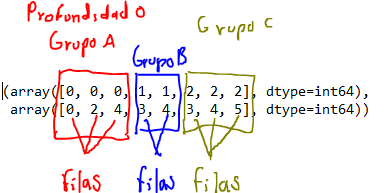

$$ \left(\begin{array}{cc} \textrm{Profundidad 0: Grupo A}\\ \textrm{Índice fila}\\ 0 \\ -\\ 2 \\ -\\ 4\\ - \end{array} \left(\begin{array}{cc} & \\ \textrm{ID} & \textrm{Cal} \\ 1 & 10 \\ - & -\\ 3 & 7.5\\ - & -\\ 5 & 9.2\\ - & - \end{array}\right)\right),\ \ \ \ \ \ \left(\begin{array}{cc} \textrm{Profundidad 1: Grupo B}\\ \textrm{Índice fila}\\ - \\ -\\ - \\ 3\\ 4\\ - \end{array} \left(\begin{array}{cc} & \\ \textrm{ID} & \textrm{Cal} \\ - & - \\ - & -\\ - & -\\ 4 & 9.5\\ 5 & 10\\ - & - \end{array}\right)\right) $$

$$ \left(\begin{array}{cc} \textrm{Profundidad 2: Grupo C}\\ \textrm{Índice fila}\\ - \\ -\\ - \\ 3\\ 4\\ 5 \end{array} \left(\begin{array}{cc} & \\ \textrm{ID} & \textrm{Cal} \\ - & - \\ - & -\\ - & -\\ 4 & 8\\ 5 & 7.2\\ 6 & 9.8 \end{array}\right)\right) $$

De tal manera, cuando obtenemos el array filtrado veremos

```python
print(array2[filtrado])
```

```
[[ 1.  10. ]
 [ 3.   7.5]
 [ 5.   9.2]
 [ 4.   9.5]
 [ 5.  10. ]
 [ 4.   8. ]
 [ 5.   7.2]
 [ 6.   9.8]]
```

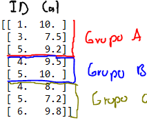

los ID y la calificación de aquellos estudiantes (de los tres grupos) que sacaron más de 7.

Ahora, el verdadero poder de `np.where()` es que podemos extraer elementos de un array que cumplen cierta condición, como vimos antes donde extrajimos los valores de los cuales la segunda columna (axis1) fuera mayor a 7, y reemplazarlos por algún otro valor; asimismo, para los elementos del array que no cumplen con dicha condición, podemos especificar cambiar su valor.

Para ver de una manera más intuitiva cómo podemos implemenatar lo anterior, consideremos ahora el siguiente array

```python
# Creamos un array de 9 filas por 9 columnas lleno de
# puros 5
array3 = np.full((9,9), 5)
print(array3)
print()

# Creamos un array identidad de la misma dimension
# que array3
array4 = np.identity(9)
print(array4)
print()

# Sumamos dichos arrays
array_sum = array3 + array4
print(array_sum)
```

```
[[5 5 5 5 5 5 5 5 5]
 [5 5 5 5 5 5 5 5 5]
 [5 5 5 5 5 5 5 5 5]
 [5 5 5 5 5 5 5 5 5]
 [5 5 5 5 5 5 5 5 5]
 [5 5 5 5 5 5 5 5 5]
 [5 5 5 5 5 5 5 5 5]
 [5 5 5 5 5 5 5 5 5]
 [5 5 5 5 5 5 5 5 5]]

[[1. 0. 0. 0. 0. 0. 0. 0. 0.]
 [0. 1. 0. 0. 0. 0. 0. 0. 0.]
 [0. 0. 1. 0. 0. 0. 0. 0. 0.]
 [0. 0. 0. 1. 0. 0. 0. 0. 0.]
 [0. 0. 0. 0. 1. 0. 0. 0. 0.]
 [0. 0. 0. 0. 0. 1. 0. 0. 0.]
 [0. 0. 0. 0. 0. 0. 1. 0. 0.]
 [0. 0. 0. 0. 0. 0. 0. 1. 0.]
 [0. 0. 0. 0. 0. 0. 0. 0. 1.]]

[[6. 5. 5. 5. 5. 5. 5. 5. 5.]
 [5. 6. 5. 5. 5. 5. 5. 5. 5.]
 [5. 5. 6. 5. 5. 5. 5. 5. 5.]
 [5. 5. 5. 6. 5. 5. 5. 5. 5.]
 [5. 5. 5. 5. 6. 5. 5. 5. 5.]
 [5. 5. 5. 5. 5. 6. 5. 5. 5.]
 [5. 5. 5. 5. 5. 5. 6. 5. 5.]
 [5. 5. 5. 5. 5. 5. 5. 6. 5.]
 [5. 5. 5. 5. 5. 5. 5. 5. 6.]]
```

```python
#                          condicion de |valor que     | valor que
#                          filtrado     |se sustituye  | se sustituye
#                                       |en caso de que| en caso de que
#                                       |la condicion  | la condicion
#                                       |sea verdadera | sea falso
filtrado_cambio = np.where(array_sum == 6,  0,         1)
# Veamos el array anterior
print(filtrado_cambio)
```

```
[[0 1 1 1 1 1 1 1 1]
 [1 0 1 1 1 1 1 1 1]
 [1 1 0 1 1 1 1 1 1]
 [1 1 1 0 1 1 1 1 1]
 [1 1 1 1 0 1 1 1 1]
 [1 1 1 1 1 0 1 1 1]
 [1 1 1 1 1 1 0 1 1]
 [1 1 1 1 1 1 1 0 1]
 [1 1 1 1 1 1 1 1 0]]
```

donde todos los elementos de la diagonal son 0 y los valores fuera de la diagonal son 1. Otro ejemplo

```python
# Consideremos el array de entradas aleatorias
# de 5 filas por 5 columnas
array5 = np.random.random((5,5))
array5
```

```
array([[0.40452917, 0.52698261, 0.27268398, 0.79717802, 0.94071403],
       [0.43568085, 0.6079667 , 0.80532758, 0.56770115, 0.39560365],
       [0.89077405, 0.88992148, 0.30093317, 0.89558492, 0.8672514 ],
       [0.8222073 , 0.71272785, 0.14634323, 0.88894845, 0.35668384],
       [0.2888239 , 0.14549937, 0.69602177, 0.31685999, 0.02948246]])
```

luego, cambiaremos los valores que son menores a 0.5 para colocar en su lugar el número 0 y cambiaremos los valores que son mayores o iguales a 0.5 para colocar en su lugar el número 1:

```python
#                          condicion de  |valor que     | valor que
#                          filtrado      |se sustituye  | se sustituye
#                                        |en caso de que| en caso de que
#                                        |la condicion  | la condicion
#                                        |sea verdadera | sea falso
filtrado_cambio2 = np.where(array5 < 0.5,   0,             1)
filtrado_cambio2
```

```
array([[0, 1, 0, 1, 1],
       [0, 1, 1, 1, 0],
       [1, 1, 0, 1, 1],
       [1, 1, 0, 1, 0],
       [0, 0, 1, 0, 0]])
```

Si observamos con atención vemos que, prácticamente, lo que hicimos fue realizar un redondeo de los números de las entradas del array `array5`.

El método `round()` aplicado a un array redondeará cada uno de los valores de las entradas de dicho array, por ejemplo

```python
print('Array original:')
print(array5)
print()

print('Array redondeado con el método round():')
print(array5.round())
print()

print('Array que redondeamos mediante una condición:')
print(filtrado_cambio2)
```

```
Array original:
[[0.40452917 0.52698261 0.27268398 0.79717802 0.94071403]
 [0.43568085 0.6079667  0.80532758 0.56770115 0.39560365]
 [0.89077405 0.88992148 0.30093317 0.89558492 0.8672514 ]
 [0.8222073  0.71272785 0.14634323 0.88894845 0.35668384]
 [0.2888239  0.14549937 0.69602177 0.31685999 0.02948246]]

Array redondeado con el método round():
[[0. 1. 0. 1. 1.]
 [0. 1. 1. 1. 0.]
 [1. 1. 0. 1. 1.]
 [1. 1. 0. 1. 0.]
 [0. 0. 1. 0. 0.]]

Array que redondeamos mediante una condición:
[[0 1 0 1 1]
 [0 1 1 1 0]
 [1 1 0 1 1]
 [1 1 0 1 0]
 [0 0 1 0 0]]
```

#### Agregar y remover datos

Comenzaremos primero uniendo (o concatenando) dos arrays y lo haremos de manera horizontal

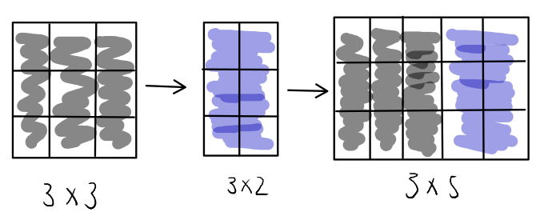

de modo que es importante, en este caso, que los arrays tengan el mismo número de filas. Así

```python
# Creamos dos arrays con el mismo numero de filas
array1 = np.zeros((3,3))
array2 = np.random.random((3,2))

# Imprimimos los arrays anteriores
print(array1)
print()
print(array2)
```

```
[[0. 0. 0.]
 [0. 0. 0.]
 [0. 0. 0.]]
[[0.60525993 0.7719087 ]
 [0.49584214 0.81364018]
 [0.55926231 0.54962566]]
```

Para concatenar dos arrays de manera horizontal utilizaremos el método `np.concatenate()`, donde como parémetro debemos asignar una tupla con los arrays que queremos unir. Por ejemplo, para unir los arrays `array1` y `array2` horizontalmente escribimos

```python
# array concatenado por columnas
array_concat = np.concatenate((array1, array2), axis=1)
array_concat
```

```
array([[0.        , 0.        , 0.        , 0.60525993, 0.7719087 ],
       [0.        , 0.        , 0.        , 0.49584214, 0.81364018],
       [0.        , 0.        , 0.        , 0.55926231, 0.54962566]])
```

que al especificar `axis=1` estamos indicando que la unión la haremos por columnas. En otras palabras, la unión horizontal no es más que unir las columnas de ambos arrays. Recordemos que, para realizar la unión horizontal, los arrays deben tener el mismo número de filas. Si queremos ahora realizar una unión vertical de arrays, es decir, unir las filas de dos arrays en uno solo

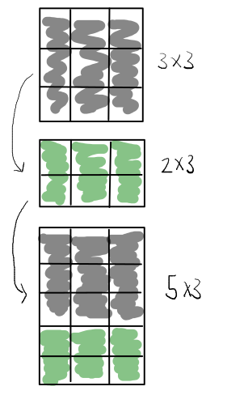

los arrays deben tener el mismo número de columnas. Y para ello configuraremos `axis=0` para especificar que la unión ahora es por filas:

```python
# Creamos dos arrays con el mismo numero de columnas
array1 = np.ones((3,3))
array2 = np.random.random((2,3))

# Imprimimos los arrays anteriores
print(array1)
print()
print(array2)
```

```
[[1. 1. 1.]
 [1. 1. 1.]
 [1. 1. 1.]]

[[0.31947663 0.55342233 0.87498701]
 [0.59711402 0.99892375 0.20750137]]
```

```python
# array concatenado por filas
array_concat = np.concatenate((array1, array2), axis=0)
array_concat
```

```
array([[1.        , 1.        , 1.        ],
       [1.        , 1.        , 1.        ],
       [1.        , 1.        , 1.        ],
       [0.31947663, 0.55342233, 0.87498701],
       [0.59711402, 0.99892375, 0.20750137]])
```

De nuevo, recuerda que las uniones que hemos visto antes sólo se pueden aplicar si las formas de los arrays involucrados son compatibles (como se mencionó antes).

Otro ejemplo, concatenemos dos arrays, donde uno de ellos tiene solo una columna

```python
# Creamos dos arrays con el mismo numero de filas
array1 = np.zeros((3,3))
array2 = np.array([1,
                   2,
                   3])

# Imprimimos los arrays anteriores
print(array1)
print()
print(array2)
```

```
[[0. 0. 0.]
 [0. 0. 0.]
 [0. 0. 0.]]

[1 2 3]
```

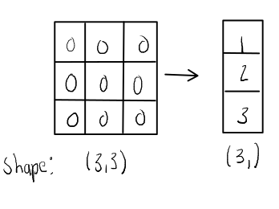

Pero, si intentamos concatenarlos obtendremos un error:

```python
# array concatenado por columnas
array_concat = np.concatenate((array1, array2), axis=1)
array_concat
```

[output not shown]

Podemos entender el error anterior si observamos las formas de ambos arrays:

```python
print(array1.shape)
print(array2.shape)
```

```
(3, 3)
(3,)
```

Pues `array2` es de una sola dimensión por lo que no tiene asociado un valor para las columnas, es decir, prácticamente se puede decir que `array2` no tiene columnas, entonces el error radica en intentar unir dos arrays por columnas, donde uno de dichos arrays no tiene columnas. Para arreglar el problema anterior escribimos

```python
#        array de 3 filas por 1 columna
array2 = array2.reshape((3,1))
array2
```

```
array([[1],
       [2],
       [3]])
```

Y ahora sí podemos unir los arrays

```python
# array concatenado por columnas
array_concat = np.concatenate((array1, array2), axis=1)
array_concat
```

```
array([[0., 0., 0., 1.],
       [0., 0., 0., 2.],
       [0., 0., 0., 3.]])
```

Por otro lado, podemos eliminar filas y/o columnas completas de un array mediante el método `np.delete()`, donde tendremos tres parámetros dentro de este método:

- Array desde el cual se hará la eliminación
- Segmento, índice o array de índices que se eliminará
- Manera de eliminar, ya sea por fila (axis 0) o por columna (axis 1).

Por ejemplo, del array `array_concat` podemos eliminar completa la fila de índice 1 (la cual sería `[0., 0., 0., 2.]`):

```python
#                    fila a  | forma de eliminacion
#                    eliminar| por filas
np.delete(array_concat, 1,    axis=0)
```

```
array([[0., 0., 0., 1.],
       [0., 0., 0., 3.]])
```

```python
# O tambien eliminar la columna de indice 3
# del array original array_concat
np.delete(array_concat, 3, axis=1)
```

```
array([[0., 0., 0.],
       [0., 0., 0.],
       [0., 0., 0.]])
```

Si no especificamos el axis, entonces nuestra array será aplanado en un array de una dimensión. Luego, si consideramos por ejemplo `np.delete(array_concat, 3)` (donde omitimos el parámetro para especificar el axis), entonces el array

```
array([[0., 0., 0., 1.],
       [0., 0., 0., 2.],
       [0., 0., 0., 3.]])
```

será aplanado al array

```
array([0., 0., 0., 1., 0., 0., 0., 2., 0., 0., 0., 3.])
```

y como especificamos el número 3 en `np.delete(array_concat, 3)`, entonces se eliminará el elemento de índice 3 del array aplanado. El elemento en la posición 3 del array aplanado es el número 1 por lo cual al escribir

```python
#                    fila a  | forma de eliminacion
#                    eliminar| por filas
np.delete(array_concat, 3)
```

```
array([0., 0., 0., 0., 0., 0., 2., 0., 0., 0., 3.])
```

ya no vemos el número 1 dentro de dicho array.

#### Resumiendo datos

En la clase pasada abordamos ya algunas formas de obtener información relevante sobre nuestros arrays. Por ejemplo

```python
# Dado el array
array1 = np.random.random((4,3))
array1
```

```
array([[0.27696186, 0.27019666, 0.29809603],
       [0.17344493, 0.59770748, 0.03401392],
       [0.25985741, 0.69146663, 0.4815255 ],
       [0.97097828, 0.61004301, 0.13910545]])
```

```python
# Obtenemos el valor maximo almacenado dentro de
# nuestro array
print(f'Valor máximo dentro de array1: {array1.max()}')
print()

# Obtenemos el valor minimo almacenado dentro de
# nuestro array
print(f'Valor mínimo dentro de array1: {array1.min()}')
```

```
Valor máximo dentro de array1: 0.9709782760399337

Valor mínimo dentro de array1: 0.034013922802112906
```

Asimismo, podemos obtener la suma de todas las entradas de nuestro array

```python
# Obtenemos la suma de todos los valores
# almacenados en nuestro array
print(f'Suma de todos los valores en array1: {array1.sum()}')
```

```
Suma de todos los valores en array1: 4.803397158051567
```

o también el promedio de los valores almacenados en nuestro array

```python
print(f'Promedio de los valores en array1: {array1.mean()}')
```

```
Promedio de los valores en array1: 0.4002830965042972
```

De manera más particular, por ejemplo, podemos obtener la suma de todos los valores de cada columna:

```python
# Para sumar por columna configuramos axis=0
array1.sum(axis=0)
```

```
array([1.68124247, 2.16941379, 0.9527409 ])
```

O también podemos sumar todos los valores de cada fila

```python
# Para sumar por fila configuramos axis=1
array1.sum(axis=1)
```

```
array([0.84525456, 0.80516633, 1.43284954, 1.72012673])
```

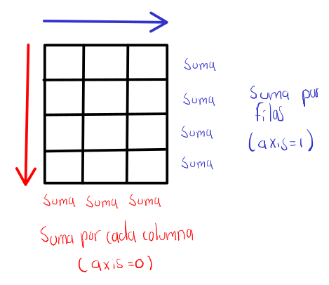

Notemos de la suma por fila que hicimos antes, que el resultado nos gustaría verlo como un array vertical (como se muestra en la imagen) y no uno horizontal como el que obtuvimos (`array([0.84525456, 0.80516633, 1.43284954, 1.72012673])`). En este caso, para que se respete la forma del array escribimos

```python
# Para sumar por fila configuramos axis=1
# Para que se respete la forma
# escribimos keepdims=true
array1.sum(axis=1, keepdims=True)
```

```
array([[0.84525456],
       [0.80516633],
       [1.43284954],
       [1.72012673]])
```

#### Operaciones vectorizadas

Las operaciones vectorizadas no son otra cosa más que las operaciones entrada a entrada que efectuabamos entre los arrays. Por ejemplo, podemos sumar cada entrada de un array con un número dado

```python
# Creamos un array
array1 = np.full((2,4), 5)
array1
```

```
array([[5, 5, 5, 5],
       [5, 5, 5, 5]])
```

```python
# sumamos el array anterior con el numero 5
array1 + 5
```

```
array([[10, 10, 10, 10],
       [10, 10, 10, 10]])
```

donde se ha operado de la siguiente manera:

$$ \left(\begin{array}{cccc} 5 & 5 & 5 & 5\\ 5 & 5 & 5 & 5 \end{array}\right) + 5 = \left(\begin{array}{cccc} 5+5 & 5+5 & 5+5 & 5+5\\ 5+5 & 5+5 & 5+5 & 5+5 \end{array}\right) = \left(\begin{array}{cccc} 10 & 10 & 10 & 10 \\ 10 & 10 & 10 & 10 \end{array}\right) $$

Otros ejemplos que bien conocemos son los siguientes:

```python
# Creamos otro array de la MISMA DIMENSION
# que el array1
array2 = np.random.random(array1.shape)
array2
```

```
array([[0.82826947, 0.29250252, 0.52894471, 0.58304645],
       [0.13864003, 0.07804048, 0.10649987, 0.2055587 ]])
```

```python
# Los multiplicamos entrada a entrada
array1 * array2
```

```
array([[4.14134734, 1.46251258, 2.64472354, 2.91523227],
       [0.69320017, 0.39020242, 0.53249937, 1.02779349]])
```

```python
# Los sumamos entradada a entrada
array1 + array2
```

```
array([[5.82826947, 5.29250252, 5.52894471, 5.58304645],
       [5.13864003, 5.07804048, 5.10649987, 5.2055587 ]])
```

etcétera. Cabe resaltar que las operaciones entre dos (o más) arrays se pueden efectuar siempre y cuando éstos tengan la misma forma.

Pero, en realidad, podemos realizar operaciones entre arrays aún cuando éstos no sean de la misma forma. Por ejemplo, cuando realizamos la operación `array1 + 5` y obtuvimos

```
array([[10, 10, 10, 10],
       [10, 10, 10, 10]])
```

lo que en realidad pasó fue que se creó internamente un array de la misma dimensión de `array1` donde todas sus entradas tenía el valor de 5. Esto es:

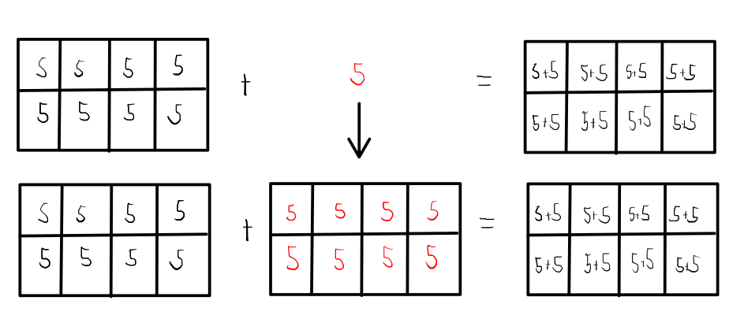

Así, podemos generalizar lo anterior para cualquier par (o más) de arrays, donde necesitaremos que al menos un valor de la forma (shape) coincida en ambos (o más) arrays, esto es, que los arrays coincidan en el número de filas, o bien, que los arrays coincidan en el número de columnas

Por ejemplo:

```python
print(array1)
print(array1.shape)
print()

# Creamos otro array
array2 = np.array([1, 2]).reshape((2,1))
print(array2)
print(array2.shape)
```

```
[[5 5 5 5]
 [5 5 5 5]]
(2, 4)

[[1]
 [2]]
(2, 1)
```

Vemos que ambos arrays coinciden en el número de filas, de modo que podemos sumar dichos arrays:

```python
array1 + array2
```

```
array([[6, 6, 6, 6],
       [7, 7, 7, 7]])
```

de donde ocurrió:

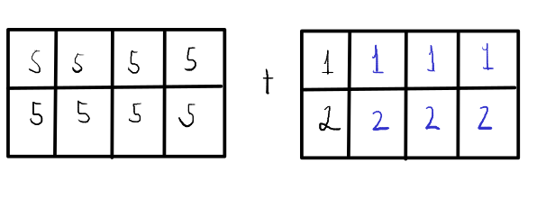

que al array $$ \left(\begin{array}{c} 1 \\ 2 \end{array}\right) \hspace{2.5cm} (\star) $$

le aumentamos 3 columnas para que tuviera la misma forma que el array `array1`, y los valores que colocamos en esas nuevas columnas son exactamente las mismas que en $(\star)$, es decir, se creó internamente la matriz:

$$ \left(\begin{array}{cccc} 1 & 1 & 1 & 1\\ 2 & 2 & 2 & 2 \end{array}\right) $$

para que se pudieran operar ambos arrays.

```python
array1 = np.array([2])
print(array1)
print(array1.shape)
print()

# Creamos otro array
array2 = np.array([1, 2]).reshape((2,1))
print(array2)
print(array2.shape)
```

```
[2]
(1,)

[[1]
 [2]]
(2, 1)
```

```python
# Multiplicamos ambos arrays
array1 * array2
```

```
array([[2],
       [4]])
```

Otro ejemplo

```python
array1 = np.array([[1,2,3,4],
                   [5,7,8,9]])
print(array1.shape)
print()

# Creamos otro array
array2 = np.array([3,3,3,3])
array2 = array2.reshape((1,4))
print(array2.shape)
```

```
(2, 4)

(1, 4)
```

```python
# Multiplicamos los arrays anteriores
array1 * array2
```

```
array([[ 3,  6,  9, 12],
       [15, 21, 24, 27]])
```

## Librería Pandas (parte 2)

#### Ordenamientos

Para trabajar en esta sección utilizaremos una base de datos sobre una encuesta realizada a estudiantes sobre un taller de matemáticas.

Así, comenzamos por importador los datos y almacenarlos en un dataframe:

```python
# Importamos pandas
import pandas as pd
# Creamos el dataframe descrito anteriormente
df = pd.read_csv('https://cursopypagina.github.io/CursoPy/Encuestas.csv')
# Accedemos a las primeras 5 filas
df.head()
```

|  | Unnamed: 0 | Marca temporal | Dirección de correo electrónico | Escribe el nombre del taller | El lenguaje de los taller fue adecuado | Se distinguió los objetivos del taller | Fueron claras las instrucciones de los talleres | ¿Qué tan ameno te pareció el taller? | Los talleres te motivaron a seguir indagando en el tema | Si tienes comentarios y/o sugerencias acerca de los talleres son bienvenidos. | El lenguaje de las secuencias didácticas te pareció apropiado | Se distinguió los objetivos de las secuencias didácticas | Fueron claros los conceptos que se formalizaron en las secuencias didácticas | ¿Qué tan complicado te pareció la formalización de los conceptos en las secuencias didácticas? | ¿Qué tan apropiado fue introducir los conceptos formales a partir de los talleres? | Si tienes comentarios y/o sugerencias son bienvenidos | El lenguaje de los talleres fue adecuado | Se distinguieron los objetivos del taller |
| --- | --- | --- | --- | --- | --- | --- | --- | --- | --- | --- | --- | --- | --- | --- | --- | --- | --- | --- |
| 0 | 0 | 21/07/2022 9:16:50 | NaN | Serpientes estocásticas y escaleras aleatorias | 1.0 | 1.0 | 1 | 1 | 2 | Sería bueno si pudieran sugerir bibliografía ú... | Mucho | Mucho | Mucho | Poco | Poco | . | NaN | NaN |
| 1 | 1 | 21/07/2022 9:18:07 | NaN | Serpientes estocásticas y escaleras aleatorias | 1.0 | 1.0 | 2 | 1 | 1 | En general el taller fue ameno, la actividad d... | Mucho | Mucho | Mucho | Mucho | Mucho | No tengo mucho que agregar, me pareció bastant... | NaN | NaN |
| 2 | 2 | 21/07/2022 9:19:09 | NaN | Serpientes estocásticas y escaleras aleatorias | 5.0 | 5.0 | 5 | 5 | 4 | No, fue agradable | Mucho | Mucho | Mucho | Mucho | Mucho | . | NaN | NaN |
| 3 | 3 | 21/07/2022 9:20:11 | NaN | Serpientes estocásticas y escaleras aleatorias | 1.0 | 1.0 | 1 | 1 | 1 | La explicación del tema fue breve y sencillo a... | Mucho | Mucho | Mucho | Poco | Mucho | El taller fue mucho de mi agrado | NaN | NaN |
| 4 | 4 | 21/07/2022 9:20:18 | NaN | Serpientes estocásticas y escaleras aleatorias | 1.0 | 1.0 | 1 | 1 | 1 | Me gusto mucho el juego de las serpientes esto... | Mucho | Mucho | Mucho | Poco | Mucho | Me gustó la parte didáctica del taller y los t... | NaN | NaN |

donde cada fila representa a un estudiante que contestó la encuesta.

Ahora bien, en la columna `El lenguaje de los taller fue adecuado` el estudiante colocará 1 si el lenguaje del taller impartido fue muy adecuado, y colocará 5 si el lenguaje fue muy poco adecuado. Así, tendría sentido, por ejemplo, ordenar nuestro dataframe en orden ascendente de acuerdo a esa columna. Antes de ello indaguemos en los nombres de las columnas de nuestro dataframe

```python
df.columns
```

```
Index(['Unnamed: 0', 'Marca temporal', 'Dirección de correo electrónico',
       'Escribe el nombre del taller ',
       'El lenguaje de los taller fue adecuado ',
       'Se distinguió los objetivos del taller',
       'Fueron claras las instrucciones de los talleres',
       '¿Qué tan ameno te pareció el taller?',
       'Los talleres te motivaron a seguir indagando en el tema',
       'Si tienes comentarios y/o sugerencias acerca de los talleres son bienvenidos.',
       'El lenguaje de las secuencias didácticas te pareció apropiado',
       'Se distinguió los objetivos de las secuencias didácticas',
       'Fueron claros los conceptos que se formalizaron en las secuencias didácticas',
       '¿Qué tan complicado te pareció la formalización de los conceptos en las secuencias didácticas?',
       '¿Qué tan apropiado fue introducir los conceptos formales a partir de los talleres?',
       'Si tienes comentarios y/o sugerencias son bienvenidos',
       'El lenguaje de los talleres fue adecuado ',
       'Se distinguieron los objetivos del taller'],
      dtype='object')
```

vemos que en realidad el nombre de la columna que nos interesa es `'El lenguaje de los taller fue adecuado '` y tiene un espacio en blanco al final, además está mal redactado el nombre de dicha columna. Entonces lo que haremos será cambiar el nombre de dicha columna, para lo cual

```python
# Creamos una lista que almacene el nombre de las columnas
# de nuestro dataframe
name_columns = list(df.columns)

# Veamos dicha lista
print(name_columns)
print()

# Cambiamos el elemento del indice 4
#                Nuevo nombre de la columna de interes
name_columns[4] = 'El lenguaje de los talleres fue adecuado'

# Vemos de nuevo la lista
print(name_columns)
```

[output not shown]

Después, configuraremos la lista creada antes como los nuevos nombres de las columnas de nuestro dataframe

```python
# Accedemos a| asignamos un
# los nombres| nuevo nombre
# de las     | a nuestras
# columnas   | columnas
df.columns =  name_columns
# Veamos los cambios
df.columns
```

```
Index(['Unnamed: 0', 'Marca temporal', 'Dirección de correo electrónico',
       'Escribe el nombre del taller ',
       'El lenguaje de los talleres fue adecuado',
       'Se distinguió los objetivos del taller',
       'Fueron claras las instrucciones de los talleres',
       '¿Qué tan ameno te pareció el taller?',
       'Los talleres te motivaron a seguir indagando en el tema',
       'Si tienes comentarios y/o sugerencias acerca de los talleres son bienvenidos.',
       'El lenguaje de las secuencias didácticas te pareció apropiado',
       'Se distinguió los objetivos de las secuencias didácticas',
       'Fueron claros los conceptos que se formalizaron en las secuencias didácticas',
       '¿Qué tan complicado te pareció la formalización de los conceptos en las secuencias didácticas?',
       '¿Qué tan apropiado fue introducir los conceptos formales a partir de los talleres?',
       'Si tienes comentarios y/o sugerencias son bienvenidos',
       'El lenguaje de los talleres fue adecuado ',
       'Se distinguieron los objetivos del taller'],
      dtype='object')
```

Así, colocamos un mejor nombre a la columna en cuestión respecto al nombre que tenía antes. De hecho, podríamos hacer lo mismo si quisieramos modificar el nombre de cualquier otra columna.

Continuando, si quieremos ordenar nuestro dataframe de acuerdo a una columna, utilizamos el método `sort_values()`, donde como parámetro va el nombre de la columna base para el ordenamiento:

```python
# Vemos las primeras filas del dataframe ordenado
df.sort_values('El lenguaje de los talleres fue adecuado').head()
```

|  | Unnamed: 0 | Marca temporal | Dirección de correo electrónico | Escribe el nombre del taller | El lenguaje de los talleres fue adecuado | Se distinguió los objetivos del taller | Fueron claras las instrucciones de los talleres | ¿Qué tan ameno te pareció el taller? | Los talleres te motivaron a seguir indagando en el tema | Si tienes comentarios y/o sugerencias acerca de los talleres son bienvenidos. | El lenguaje de las secuencias didácticas te pareció apropiado | Se distinguió los objetivos de las secuencias didácticas | Fueron claros los conceptos que se formalizaron en las secuencias didácticas | ¿Qué tan complicado te pareció la formalización de los conceptos en las secuencias didácticas? | ¿Qué tan apropiado fue introducir los conceptos formales a partir de los talleres? | Si tienes comentarios y/o sugerencias son bienvenidos | El lenguaje de los talleres fue adecuado | Se distinguieron los objetivos del taller |
| --- | --- | --- | --- | --- | --- | --- | --- | --- | --- | --- | --- | --- | --- | --- | --- | --- | --- | --- |
| 0 | 0 | 21/07/2022 9:16:50 | NaN | Serpientes estocásticas y escaleras aleatorias | 1.0 | 1.0 | 1 | 1 | 2 | Sería bueno si pudieran sugerir bibliografía ú... | Mucho | Mucho | Mucho | Poco | Poco | . | NaN | NaN |
| 105 | 14 | 21/07/2022 9:57:18 | NaN | ¿Leonardo DiCaprio es perfecto? | 1.0 | 1.0 | 1 | 1 | 1 | Me pareció un taller muy interesante y útil. | Mucho | Mucho | Mucho | Poco | Mucho | Ninguno | NaN | NaN |
| 102 | 11 | 21/07/2022 9:14:38 | NaN | ¿Leonardo Di caprio es perfecto? | 1.0 | 2.0 | 1 | 1 | 2 | Fue un taller interesante, toco temas que sola... | Mucho | Mucho | Mucho | Poco | Mucho | Los materiales o temas ocupados a lo largo del... | NaN | NaN |
| 101 | 10 | 21/07/2022 9:13:03 | NaN | ¿Leonardo DiCaprio es perfecto? | 1.0 | 1.0 | 1 | 1 | 1 | Me gustó mucho el taller, explicaron todo muy ... | Mucho | Mucho | Mucho | Poco | Mucho | Las presentaciones fueron muy claras y por lo ... | NaN | NaN |
| 99 | 8 | 21/07/2022 9:12:54 | NaN | ¿Leonardo Di Caprio es perfecto? | 1.0 | 1.0 | 1 | 1 | 1 | Me agradó la disposición de los instructores d... | Mucho | Mucho | Mucho | Poco | Mucho | Me gustó que la secuencia didactica fue muy in... | NaN | NaN |

```python
# Veamos unas filas en especifico donde podemos ver de manera
# mas visual el ordenamiento que hicimos
df.sort_values('El lenguaje de los talleres fue adecuado')[114:130]
```

|  | Unnamed: 0 | Marca temporal | Dirección de correo electrónico | Escribe el nombre del taller | El lenguaje de los talleres fue adecuado | Se distinguió los objetivos del taller | Fueron claras las instrucciones de los talleres | ¿Qué tan ameno te pareció el taller? | Los talleres te motivaron a seguir indagando en el tema | Si tienes comentarios y/o sugerencias acerca de los talleres son bienvenidos. | El lenguaje de las secuencias didácticas te pareció apropiado | Se distinguió los objetivos de las secuencias didácticas | Fueron claros los conceptos que se formalizaron en las secuencias didácticas | ¿Qué tan complicado te pareció la formalización de los conceptos en las secuencias didácticas? | ¿Qué tan apropiado fue introducir los conceptos formales a partir de los talleres? | Si tienes comentarios y/o sugerencias son bienvenidos | El lenguaje de los talleres fue adecuado | Se distinguieron los objetivos del taller |
| --- | --- | --- | --- | --- | --- | --- | --- | --- | --- | --- | --- | --- | --- | --- | --- | --- | --- | --- |
| 113 | 7 | 21/07/2022 9:17:42 | NaN | Scrampty | 2.0 | 2.0 | 1 | 1 | 1 | No. | Mucho | Mucho | Mucho | Mucho | Mucho | No. | NaN | NaN |
| 107 | 1 | 21/07/2022 9:14:57 | NaN | Scrampin | 2.0 | 2.0 | 1 | 2 | 2 | Todo bien :) | Mucho | Mucho | Mucho | Poco | Mucho | Todo claro | NaN | NaN |
| 133 | 4 | 21/07/2022 9:14:24 | NaN | Toros vacas | 3.0 | 2.0 | 1 | 2 | 2 | por el momento no, gracias | Mucho | Mucho | Mucho | Poco | Poco | respondiendo a la anterior pregunta, no es ni ... | NaN | NaN |
| 67 | 0 | 21/07/2022 12:04:11 | NaN | Un algoritmo para calcular el día del fin del ... | 4.0 | 5.0 | 4 | 3 | 2 | Me gustó el taller | Mucho | Mucho | Mucho | Poco | Mucho | Estuvo interesante conocer el concepto de indu... | NaN | NaN |
| 88 | 9 | 21/07/2022 12:13:23 | NaN | El juego del grafimar | 4.0 | 4.0 | 4 | 4 | 1 | ninguno | Mucho | Mucho | Mucho | Mucho | Mucho | ninguno | NaN | NaN |
| 74 | 7 | 21/07/2022 12:07:13 | NaN | Ecuación para calcular el fin del mundo | 4.0 | 4.0 | 4 | 4 | 3 | Todo bien, sólo hubo unas partes que no entendí. | Mucho | Mucho | Poco | Mucho | Mucho | Todo bien | NaN | NaN |
| 76 | 9 | 21/07/2022 12:09:01 | NaN | Un algoritmo para calcular el día del fin del ... | 4.0 | 5.0 | 4 | 5 | 5 | nop :)) | Mucho | Mucho | Poco | Mucho | Mucho | :)) | NaN | NaN |
| 112 | 6 | 21/07/2022 9:17:16 | NaN | Scram∅ | 4.0 | 5.0 | 5 | 5 | 5 | . | Mucho | Mucho | Mucho | Mucho | Mucho | . | NaN | NaN |
| 103 | 12 | 21/07/2022 9:17:19 | NaN | Cursos Propedéuticos Facultad de Ciencias | 4.0 | 4.0 | 4 | 4 | 4 | - | Mucho | Mucho | Mucho | Mucho | Mucho | - | NaN | NaN |
| 60 | 1 | 21/07/2022 12:19:19 | NaN | Cursos Propedéuticos Facultad de Ciencias | 4.0 | 3.0 | 4 | 3 | 3 | Todo bien | Mucho | Poco | Mucho | Mucho | Poco | Me ha gustado mucho el taller y la secuencia d... | NaN | NaN |
| 122 | 5 | 21/07/2022 9:11:21 | NaN | Maquina para transformar café en teoremas | 4.0 | 3.0 | 5 | 5 | 5 | El taller en general me gustó bastante, pues c... | Mucho | Poco | Mucho | Poco | Mucho | La formalización de conceptos me ayudó a compr... | NaN | NaN |
| 51 | 5 | 21/07/2022 12:16:56 | NaN | Los caminos del infinito | 5.0 | 5.0 | 4 | 5 | 5 | Que entregaran un pdf con la info del taller. | Mucho | Mucho | Mucho | Mucho | Mucho | - | NaN | NaN |
| 114 | 8 | 21/07/2022 9:18:37 | NaN | scrampty | 5.0 | 5.0 | 2 | 1 | 2 | El taller fue muy ameno, fácil y divertido | Mucho | Mucho | Mucho | Poco | Mucho | Me gustó mucho jugar scrable | NaN | NaN |
| 62 | 3 | 21/07/2022 12:19:51 | NaN | Curso Propedéutico Facultad de Ciencias | 5.0 | 5.0 | 5 | 5 | 5 | Me parecieron correctas las dos clases que he ... | Mucho | Mucho | Mucho | Mucho | Mucho | Todo esta super bien con los talleres hasta ahora | NaN | NaN |
| 44 | 11 | 21/07/2022 12:22:49 | NaN | Carrera de Probabilidades con Mario Kart. | 5.0 | 5.0 | 5 | 5 | 5 | Dar bibliografia de materias de tronco comun | Mucho | Mucho | Mucho | Poco | Mucho | Formar los grupos con aspirantes de una misma ... | NaN | NaN |
| 97 | 6 | 21/07/2022 9:12:35 | NaN | Propedéutico facultad de ciencias | 5.0 | 4.0 | 4 | 5 | 4 | Ninguno | Mucho | Mucho | Mucho | Poco | Mucho | Ninguno | NaN | NaN |

Vemos que se ha realizado el ordenamiento de manera ascendente como queríamos. Cabe resaltar que nuestros datos aún no han sido limpiados, es decir, tenemos varios datos faltantes (que tienen la etiqueta `NaN`) en nuestras columnas. Es por ello que si queremos ver las últimas filas del dataframe ordenado veremos

```python
df.sort_values('El lenguaje de los talleres fue adecuado').tail()
```

|  | Unnamed: 0 | Marca temporal | Dirección de correo electrónico | Escribe el nombre del taller | El lenguaje de los talleres fue adecuado | Se distinguió los objetivos del taller | Fueron claras las instrucciones de los talleres | ¿Qué tan ameno te pareció el taller? | Los talleres te motivaron a seguir indagando en el tema | Si tienes comentarios y/o sugerencias acerca de los talleres son bienvenidos. | El lenguaje de las secuencias didácticas te pareció apropiado | Se distinguió los objetivos de las secuencias didácticas | Fueron claros los conceptos que se formalizaron en las secuencias didácticas | ¿Qué tan complicado te pareció la formalización de los conceptos en las secuencias didácticas? | ¿Qué tan apropiado fue introducir los conceptos formales a partir de los talleres? | Si tienes comentarios y/o sugerencias son bienvenidos | El lenguaje de los talleres fue adecuado | Se distinguieron los objetivos del taller |
| --- | --- | --- | --- | --- | --- | --- | --- | --- | --- | --- | --- | --- | --- | --- | --- | --- | --- | --- |
| 28 | 7 | 21/07/2022 16:22:50 | NaN | Juntos con conjuntos | NaN | NaN | 1 | 1 | 1 | Me gustó mucho el taller, repasé cosas que se ... | Mucho | Mucho | Mucho | Poco | Mucho | clases muy completas!:) | 1.0 | 1.0 |
| 29 | 8 | 21/07/2022 16:23:05 | NaN | Conjuntos ? | NaN | NaN | 1 | 1 | 1 | Sofia, a veces te ponías un poco nerviosa y no... | Mucho | Mucho | Mucho | Poco | Mucho | Sin comentarios | 1.0 | 1.0 |
| 30 | 9 | 21/07/2022 16:23:50 | NaN | Juntos con conjuntos | NaN | NaN | 1 | 3 | 3 | Creo que faltó que dieran como un "puente" por... | Mucho | Poco | Mucho | Poco | Poco | Ninguno | 2.0 | 3.0 |
| 31 | 10 | 21/07/2022 16:23:59 | NaN | Juntos con conjuntos | NaN | NaN | 1 | 2 | 2 | considero que fue buena la explicación y el ma... | Mucho | Mucho | Mucho | Mucho | Mucho | todo me pareció muy bien | 2.0 | 2.0 |
| 32 | 11 | 21/07/2022 16:24:46 | NaN | Juntos con conjuntos | NaN | NaN | 1 | 1 | 1 | Sólo me gustaría agradecer la labor y dinámica... | Mucho | Mucho | Mucho | Poco | Mucho | El material usado facilitó mucho el aprendizaj... | 1.0 | 1.0 |

que se muestran los valores `NaN` para la columna `'El lenguaje de los talleres fue adecuado'`, lo cual podría compromenter nuestro análisis. De ahí la importancia de siempre realizar una "limpieza" de los datos y, por ejemplo, eliminar o modificar esos valores faltantes (NaN). No realizaremos la limpieza de los datos pues queda fuera de los objetivos de esta clase.

Continuando, podemos ordenar ahora de manera descendente para lo cual agregaremos el parámetro `ascending=False` como sigue:

```python
df.sort_values('El lenguaje de los talleres fue adecuado', ascending=False).head()
```

|  | Unnamed: 0 | Marca temporal | Dirección de correo electrónico | Escribe el nombre del taller | El lenguaje de los talleres fue adecuado | Se distinguió los objetivos del taller | Fueron claras las instrucciones de los talleres | ¿Qué tan ameno te pareció el taller? | Los talleres te motivaron a seguir indagando en el tema | Si tienes comentarios y/o sugerencias acerca de los talleres son bienvenidos. | El lenguaje de las secuencias didácticas te pareció apropiado | Se distinguió los objetivos de las secuencias didácticas | Fueron claros los conceptos que se formalizaron en las secuencias didácticas | ¿Qué tan complicado te pareció la formalización de los conceptos en las secuencias didácticas? | ¿Qué tan apropiado fue introducir los conceptos formales a partir de los talleres? | Si tienes comentarios y/o sugerencias son bienvenidos | El lenguaje de los talleres fue adecuado | Se distinguieron los objetivos del taller |
| --- | --- | --- | --- | --- | --- | --- | --- | --- | --- | --- | --- | --- | --- | --- | --- | --- | --- | --- |
| 51 | 5 | 21/07/2022 12:16:56 | NaN | Los caminos del infinito | 5.0 | 5.0 | 4 | 5 | 5 | Que entregaran un pdf con la info del taller. | Mucho | Mucho | Mucho | Mucho | Mucho | - | NaN | NaN |
| 2 | 2 | 21/07/2022 9:19:09 | NaN | Serpientes estocásticas y escaleras aleatorias | 5.0 | 5.0 | 5 | 5 | 4 | No, fue agradable | Mucho | Mucho | Mucho | Mucho | Mucho | . | NaN | NaN |
| 114 | 8 | 21/07/2022 9:18:37 | NaN | scrampty | 5.0 | 5.0 | 2 | 1 | 2 | El taller fue muy ameno, fácil y divertido | Mucho | Mucho | Mucho | Poco | Mucho | Me gustó mucho jugar scrable | NaN | NaN |
| 45 | 12 | 21/07/2022 12:22:52 | NaN | carrera de probabilidades con Mario kart | 5.0 | 5.0 | 5 | 5 | 5 | todo bien | Mucho | Mucho | Mucho | Mucho | Mucho | todo bien | NaN | NaN |
| 44 | 11 | 21/07/2022 12:22:49 | NaN | Carrera de Probabilidades con Mario Kart. | 5.0 | 5.0 | 5 | 5 | 5 | Dar bibliografia de materias de tronco comun | Mucho | Mucho | Mucho | Poco | Mucho | Formar los grupos con aspirantes de una misma ... | NaN | NaN |

Podemos también realizar el ordenamiento tomando como base dos columnas en vez de una:

```python
# Para ordenar con base en dos columnas requeriremos
# escribir el nombre de dichas columnas
# dentro de una lista
df.sort_values( [ 'El lenguaje de los talleres fue adecuado',
                'Se distinguió los objetivos del taller' ],
                # configuramos el ordenamiento de manera
                # descendente
                ascending=False).head()
```

|  | Unnamed: 0 | Marca temporal | Dirección de correo electrónico | Escribe el nombre del taller | El lenguaje de los talleres fue adecuado | Se distinguió los objetivos del taller | Fueron claras las instrucciones de los talleres | ¿Qué tan ameno te pareció el taller? | Los talleres te motivaron a seguir indagando en el tema | Si tienes comentarios y/o sugerencias acerca de los talleres son bienvenidos. | El lenguaje de las secuencias didácticas te pareció apropiado | Se distinguió los objetivos de las secuencias didácticas | Fueron claros los conceptos que se formalizaron en las secuencias didácticas | ¿Qué tan complicado te pareció la formalización de los conceptos en las secuencias didácticas? | ¿Qué tan apropiado fue introducir los conceptos formales a partir de los talleres? | Si tienes comentarios y/o sugerencias son bienvenidos | El lenguaje de los talleres fue adecuado | Se distinguieron los objetivos del taller |
| --- | --- | --- | --- | --- | --- | --- | --- | --- | --- | --- | --- | --- | --- | --- | --- | --- | --- | --- |
| 2 | 2 | 21/07/2022 9:19:09 | NaN | Serpientes estocásticas y escaleras aleatorias | 5.0 | 5.0 | 5 | 5 | 4 | No, fue agradable | Mucho | Mucho | Mucho | Mucho | Mucho | . | NaN | NaN |
| 44 | 11 | 21/07/2022 12:22:49 | NaN | Carrera de Probabilidades con Mario Kart. | 5.0 | 5.0 | 5 | 5 | 5 | Dar bibliografia de materias de tronco comun | Mucho | Mucho | Mucho | Poco | Mucho | Formar los grupos con aspirantes de una misma ... | NaN | NaN |
| 45 | 12 | 21/07/2022 12:22:52 | NaN | carrera de probabilidades con Mario kart | 5.0 | 5.0 | 5 | 5 | 5 | todo bien | Mucho | Mucho | Mucho | Mucho | Mucho | todo bien | NaN | NaN |
| 51 | 5 | 21/07/2022 12:16:56 | NaN | Los caminos del infinito | 5.0 | 5.0 | 4 | 5 | 5 | Que entregaran un pdf con la info del taller. | Mucho | Mucho | Mucho | Mucho | Mucho | - | NaN | NaN |
| 62 | 3 | 21/07/2022 12:19:51 | NaN | Curso Propedéutico Facultad de Ciencias | 5.0 | 5.0 | 5 | 5 | 5 | Me parecieron correctas las dos clases que he ... | Mucho | Mucho | Mucho | Mucho | Mucho | Todo esta super bien con los talleres hasta ahora | NaN | NaN |

Asimismo, podemos configurar que una de las columnas tenga un ordenamiento de manera descendente y la otra de manera ascendente

```python
df.sort_values( [ 'El lenguaje de los talleres fue adecuado',
                'Se distinguió los objetivos del taller' ],
                # configuramos el ordenamiento de manera
                # descendente para la primer columna
                # y de manera ascendente para la
                # segunda
                ascending=[False, True]).head()
```

|  | Unnamed: 0 | Marca temporal | Dirección de correo electrónico | Escribe el nombre del taller | El lenguaje de los talleres fue adecuado | Se distinguió los objetivos del taller | Fueron claras las instrucciones de los talleres | ¿Qué tan ameno te pareció el taller? | Los talleres te motivaron a seguir indagando en el tema | Si tienes comentarios y/o sugerencias acerca de los talleres son bienvenidos. | El lenguaje de las secuencias didácticas te pareció apropiado | Se distinguió los objetivos de las secuencias didácticas | Fueron claros los conceptos que se formalizaron en las secuencias didácticas | ¿Qué tan complicado te pareció la formalización de los conceptos en las secuencias didácticas? | ¿Qué tan apropiado fue introducir los conceptos formales a partir de los talleres? | Si tienes comentarios y/o sugerencias son bienvenidos | El lenguaje de los talleres fue adecuado | Se distinguieron los objetivos del taller |
| --- | --- | --- | --- | --- | --- | --- | --- | --- | --- | --- | --- | --- | --- | --- | --- | --- | --- | --- |
| 97 | 6 | 21/07/2022 9:12:35 | NaN | Propedéutico facultad de ciencias | 5.0 | 4.0 | 4 | 5 | 4 | Ninguno | Mucho | Mucho | Mucho | Poco | Mucho | Ninguno | NaN | NaN |
| 126 | 9 | 21/07/2022 9:12:23 | NaN | Máquina para transformar café en teoremas | 5.0 | 4.0 | 5 | 5 | 5 | Despiertan mucho el interés en aprender | Mucho | Mucho | Mucho | Poco | Mucho | Es muy dinámico y mantiene la atención enfocad... | NaN | NaN |
| 2 | 2 | 21/07/2022 9:19:09 | NaN | Serpientes estocásticas y escaleras aleatorias | 5.0 | 5.0 | 5 | 5 | 4 | No, fue agradable | Mucho | Mucho | Mucho | Mucho | Mucho | . | NaN | NaN |
| 44 | 11 | 21/07/2022 12:22:49 | NaN | Carrera de Probabilidades con Mario Kart. | 5.0 | 5.0 | 5 | 5 | 5 | Dar bibliografia de materias de tronco comun | Mucho | Mucho | Mucho | Poco | Mucho | Formar los grupos con aspirantes de una misma ... | NaN | NaN |
| 45 | 12 | 21/07/2022 12:22:52 | NaN | carrera de probabilidades con Mario kart | 5.0 | 5.0 | 5 | 5 | 5 | todo bien | Mucho | Mucho | Mucho | Mucho | Mucho | todo bien | NaN | NaN |

#### Filtros

Por otro lado, así como realizabamos filtros en NumPy, podemos realizar filtros en pandas.

Antes de continuar haremos más pequeño el dataframe con el que estamos trabajando para tener mayor comodidad

```python
# Vemos de nuevos los nombres de las columnas
df.columns
```

```
Index(['Unnamed: 0', 'Marca temporal', 'Dirección de correo electrónico',
       'Escribe el nombre del taller ',
       'El lenguaje de los talleres fue adecuado',
       'Se distinguió los objetivos del taller',
       'Fueron claras las instrucciones de los talleres',
       '¿Qué tan ameno te pareció el taller?',
       'Los talleres te motivaron a seguir indagando en el tema',
       'Si tienes comentarios y/o sugerencias acerca de los talleres son bienvenidos.',
       'El lenguaje de las secuencias didácticas te pareció apropiado',
       'Se distinguió los objetivos de las secuencias didácticas',
       'Fueron claros los conceptos que se formalizaron en las secuencias didácticas',
       '¿Qué tan complicado te pareció la formalización de los conceptos en las secuencias didácticas?',
       '¿Qué tan apropiado fue introducir los conceptos formales a partir de los talleres?',
       'Si tienes comentarios y/o sugerencias son bienvenidos',
       'El lenguaje de los talleres fue adecuado ',
       'Se distinguieron los objetivos del taller'],
      dtype='object')
```

```python
# Nos quedaremos solo con 3 columnas
df2 = df[['Escribe el nombre del taller ',
          'El lenguaje de los talleres fue adecuado',
          'Se distinguió los objetivos del taller']]
df2.head()
```

|  | Escribe el nombre del taller | El lenguaje de los talleres fue adecuado | Se distinguió los objetivos del taller |
| --- | --- | --- | --- |
| 0 | Serpientes estocásticas y escaleras aleatorias | 1.0 | 1.0 |
| 1 | Serpientes estocásticas y escaleras aleatorias | 1.0 | 1.0 |
| 2 | Serpientes estocásticas y escaleras aleatorias | 5.0 | 5.0 |
| 3 | Serpientes estocásticas y escaleras aleatorias | 1.0 | 1.0 |
| 4 | Serpientes estocásticas y escaleras aleatorias | 1.0 | 1.0 |

De tal manera, podemos crear un primer filtro

```python
# Filtro: Valores de la columna
# 'El lenguaje de los talleres fue adecuado'
# que sean mayores o iguales a 4:
df2['El lenguaje de los talleres fue adecuado'] >= 4
```

```
0      False
1      False
2       True
3      False
4      False
       ...
140    False
141    False
142    False
143    False
144    False
Name: El lenguaje de los talleres fue adecuado, Length: 145, dtype: bool
```

Vemos que obtenemos una tabla con entradas booleanas, donde `True` indica que el valor en dicha entrada cumple con la condición que especificamos y `False` caso contrario. Luego, para obtener explícitamente las filas del dataframe que cumplen con la condición, escribimos:

```python
df2[ df2['El lenguaje de los talleres fue adecuado'] >= 4 ]
```

|  | Escribe el nombre del taller | El lenguaje de los talleres fue adecuado | Se distinguió los objetivos del taller |
| --- | --- | --- | --- |
| 2 | Serpientes estocásticas y escaleras aleatorias | 5.0 | 5.0 |
| 44 | Carrera de Probabilidades con Mario Kart. | 5.0 | 5.0 |
| 45 | carrera de probabilidades con Mario kart | 5.0 | 5.0 |
| 51 | Los caminos del infinito | 5.0 | 5.0 |
| 60 | Cursos Propedéuticos Facultad de Ciencias | 4.0 | 3.0 |
| 62 | Curso Propedéutico Facultad de Ciencias | 5.0 | 5.0 |
| 67 | Un algoritmo para calcular el día del fin del ... | 4.0 | 5.0 |
| 74 | Ecuación para calcular el fin del mundo | 4.0 | 4.0 |
| 76 | Un algoritmo para calcular el día del fin del ... | 4.0 | 5.0 |
| 88 | El juego del grafimar | 4.0 | 4.0 |
| 97 | Propedéutico facultad de ciencias | 5.0 | 4.0 |
| 103 | Cursos Propedéuticos Facultad de Ciencias | 4.0 | 4.0 |
| 112 | Scram∅ | 4.0 | 5.0 |
| 114 | scrampty | 5.0 | 5.0 |
| 122 | Maquina para transformar café en teoremas | 4.0 | 3.0 |
| 126 | Máquina para transformar café en teoremas | 5.0 | 4.0 |

Veamos ahora a aquellos estudiantes que calificaron con un valor menor o igual a 2 respecto a la pregunta de la columna `'El lenguaje de los talleres fue adecuado'`

```python
#    ---------------condicion de filtrado----------------
df2[ df2['El lenguaje de los talleres fue adecuado'] <= 2 ]
```

|  | Escribe el nombre del taller | El lenguaje de los talleres fue adecuado | Se distinguió los objetivos del taller |
| --- | --- | --- | --- |
| 0 | Serpientes estocásticas y escaleras aleatorias | 1.0 | 1.0 |
| 1 | Serpientes estocásticas y escaleras aleatorias | 1.0 | 1.0 |
| 3 | Serpientes estocásticas y escaleras aleatorias | 1.0 | 1.0 |
| 4 | Serpientes estocásticas y escaleras aleatorias | 1.0 | 1.0 |
| 5 | Serpientes estocásticas y escaleras aleatorias | 1.0 | 2.0 |
| ... | ... | ... | ... |
| 140 | Maquina para transformar cafe en teoremas | 1.0 | 1.0 |
| 141 | TOROS Y VACAS | 1.0 | 1.0 |
| 142 | maquina para transformar café en teoremas | 1.0 | 2.0 |
| 143 | Maquina para transformar café en teoremas | 1.0 | 1.0 |
| 144 | Maquina para transformar café en teoremas | 1.0 | 1.0 |

116 rows × 3 columns

de modo la mayoría de las calificaciones fueron buenas (recordemos que 1 es una muy buena calificación y 5 una muy mala calificación). Podemos utilizar filtros más complejos utilizando *and* (&) y *or* (|) como sigue

```python
# Condiciones de filtrado
condicion1 =  df2['El lenguaje de los talleres fue adecuado'] == 3
condicion2 =  df2['El lenguaje de los talleres fue adecuado'] == 5

# Filtro: se cumple la condicion 1 o se cumple la condicion 2
df2[ condicion1 | condicion2 ]
```

|  | Escribe el nombre del taller | El lenguaje de los talleres fue adecuado | Se distinguió los objetivos del taller |
| --- | --- | --- | --- |
| 2 | Serpientes estocásticas y escaleras aleatorias | 5.0 | 5.0 |
| 44 | Carrera de Probabilidades con Mario Kart. | 5.0 | 5.0 |
| 45 | carrera de probabilidades con Mario kart | 5.0 | 5.0 |
| 51 | Los caminos del infinito | 5.0 | 5.0 |
| 62 | Curso Propedéutico Facultad de Ciencias | 5.0 | 5.0 |
| 97 | Propedéutico facultad de ciencias | 5.0 | 4.0 |
| 114 | scrampty | 5.0 | 5.0 |
| 126 | Máquina para transformar café en teoremas | 5.0 | 4.0 |
| 133 | Toros vacas | 3.0 | 2.0 |

De manera similar podemos escribir

```python
# Condiciones de filtrado
condicion1 =  df2['Escribe el nombre del taller '] == 'Toros vacas '
# De manera alternativa, en vez de escribir == 3 como se ve abajo,
# podemos usar df2['El lenguaje de los talleres fue adecuado'].eq(3)
condicion2 =  df2['El lenguaje de los talleres fue adecuado'] == 3

# Filtro: se cumple la condicion 1 y se cumple la condicion 2
df2[ condicion1 & condicion2 ]
```

|  | Escribe el nombre del taller | El lenguaje de los talleres fue adecuado | Se distinguió los objetivos del taller |
| --- | --- | --- | --- |
| 133 | Toros vacas | 3.0 | 2.0 |

Notamos otro punto importante, es necesario hacer limpieza a nuestros datos pues vemos que un estudiante ha ingresado el nombre del taller `'Toros vacas '` colocando un espacio en blanco al final.

Otra manera de filtrar puede ser:

```python
# Condicion de filtrado:
#                  Columna de interes                     valores posibles
cond = df2['El lenguaje de los talleres fue adecuado'].isin( [0, 4] )

# Consideraremos las entradas de nuestro dataframe donde los valores
# de la columna 'El lenguaje de los talleres fue adecuado' sean el 0
# o el 4
df2[cond]
```

|  | Escribe el nombre del taller | El lenguaje de los talleres fue adecuado | Se distinguió los objetivos del taller |
| --- | --- | --- | --- |
| 60 | Cursos Propedéuticos Facultad de Ciencias | 4.0 | 3.0 |
| 67 | Un algoritmo para calcular el día del fin del ... | 4.0 | 5.0 |
| 74 | Ecuación para calcular el fin del mundo | 4.0 | 4.0 |
| 76 | Un algoritmo para calcular el día del fin del ... | 4.0 | 5.0 |
| 88 | El juego del grafimar | 4.0 | 4.0 |
| 103 | Cursos Propedéuticos Facultad de Ciencias | 4.0 | 4.0 |
| 112 | Scram∅ | 4.0 | 5.0 |
| 122 | Maquina para transformar café en teoremas | 4.0 | 3.0 |

esto es, con el método `isin([<lista de valores>])` aplicado a una columna, estamos filtrando los valores de dicha columna que sean iguales a alguna de las posibilidades enmarcadas en la lista `[<lista de valores>]`. De tal manera, al escribir

```
df2['El lenguaje de los talleres fue adecuado'].isin( [0, 4] )
```

estamos considerando los valores de la columna `'El lenguaje de los talleres fue adecuado'` que tengan el valor de 0 o que tengan el valor de 4 asignado